# Crim Patterns in Chicago

Paul Olulana

2024-12-12

## Introduction

This report explores crime patterns in Chicago using a comprehensive analysis of 2015 data from the City of Chicago Open Data Portal. By leveraging R’s powerful data manipulation and visualization tools, the study examines temporal trends, such as variations in crime by month and hour, as well as geospatial patterns, with a focus on identifying violent crime hotspots across neighborhoods. The objective is to uncover actionable insights that can inform data-driven strategies for crime prevention and resource allocation, ultimately contributing to improved public safety and urban management.

[figure not shown]

## Data Preparation

### Loading the Dataset

```
## 'data.frame':    264863 obs. of  22 variables:
##  $ ID                  : int  11645527 11037294 11650748 11653302 11653363 10060236 11656174 11709926 11709452 11609786 ...
##  $ Case.Number         : chr  "JC212744" "JA371270" "JC218863" "JC221559" ...
##  $ Date                : chr  "02/02/2015 10:00:00 AM" "03/18/2015 12:00:00 PM" "04/01/2015 09:00:00 AM" "07/30/2015 10:25:00 AM" ...
##  $ Block               : chr  "069XX W ARCHER AVE" "0000X W WACKER DR" "011XX W 15TH ST" "036XX W GRENSHAW ST" ...
##  $ IUCR                : chr  "1153" "1153" "5000" "1153" ...
##  $ Primary.Type        : chr  "DECEPTIVE PRACTICE" "DECEPTIVE PRACTICE" "OTHER OFFENSE" "DECEPTIVE PRACTICE" ...
##  $ Description         : chr  "FINANCIAL IDENTITY THEFT OVER $ 300" "FINANCIAL IDENTITY THEFT OVER $ 300" "OTHER CRIME AGAINST PERSON" "FINANCIAL IDENTITY THEFT OVER $ 300" ...
##  $ Location.Description: chr  "OTHER" "BANK" "RESIDENCE" "" ...
##  $ Arrest              : chr  "false" "false" "false" "false" ...
##  $ Domestic            : chr  "false" "false" "false" "false" ...
##  $ Beat                : int  811 111 1232 1133 1112 322 312 1225 2533 2532 ...
##  $ District            : int  8 1 12 11 11 3 3 12 25 25 ...
##  $ Ward                : int  23 42 11 24 27 6 20 27 36 37 ...
##  $ Community.Area      : int  56 32 28 29 23 69 42 28 20 25 ...
##  $ FBI.Code            : chr  "11" "11" "26" "11" ...
##  $ X.Coordinate        : int  NA NA NA NA NA NA NA NA NA NA ...
##  $ Y.Coordinate        : int  NA NA NA NA NA NA NA NA NA NA ...
##  $ Year                : int  2015 2015 2015 2015 2015 2015 2015 2015 2015 2015 ...
##  $ Updated.On          : chr  "04/06/2019 04:04:43 PM" "08/01/2017 03:52:26 PM" "04/11/2019 04:07:22 PM" "04/13/2019 04:01:56 PM" ...
##  $ Latitude            : num  NA NA NA NA NA NA NA NA NA NA ...
##  $ Longitude           : num  NA NA NA NA NA NA NA NA NA NA ...
##  $ Location            : chr  "" "" "" "" ...
```

```
##         ID Case.Number                   Date                Block IUCR
## 1 11645527    JC212744 02/02/2015 10:00:00 AM   069XX W ARCHER AVE 1153
## 2 11037294    JA371270 03/18/2015 12:00:00 PM    0000X W WACKER DR 1153
## 3 11650748    JC218863 04/01/2015 09:00:00 AM      011XX W 15TH ST 5000
## 4 11653302    JC221559 07/30/2015 10:25:00 AM  036XX W GRENSHAW ST 1153
## 5 11653363    JC222212 12/28/2015 09:00:00 AM 010XX N RIDGEWAY AVE 1153
## 6 10060236    HY189559 03/18/2015 01:50:07 PM      001XX E 70TH ST 2024
##         Primary.Type                         Description Location.Description
## 1 DECEPTIVE PRACTICE FINANCIAL IDENTITY THEFT OVER $ 300                OTHER
## 2 DECEPTIVE PRACTICE FINANCIAL IDENTITY THEFT OVER $ 300                 BANK
## 3      OTHER OFFENSE          OTHER CRIME AGAINST PERSON            RESIDENCE
## 4 DECEPTIVE PRACTICE FINANCIAL IDENTITY THEFT OVER $ 300
## 5 DECEPTIVE PRACTICE FINANCIAL IDENTITY THEFT OVER $ 300            APARTMENT
## 6          NARCOTICS                 POSS: HEROIN(WHITE)            RESIDENCE
##   Arrest Domestic Beat District Ward Community.Area FBI.Code X.Coordinate
## 1  false    false  811        8   23             56       11           NA
## 2  false    false  111        1   42             32       11           NA
## 3  false    false 1232       12   11             28       26           NA
## 4  false    false 1133       11   24             29       11           NA
## 5  false    false 1112       11   27             23       11           NA
## 6   true    false  322        3    6             69       18           NA
##   Y.Coordinate Year             Updated.On Latitude Longitude Location
## 1           NA 2015 04/06/2019 04:04:43 PM       NA        NA
## 2           NA 2015 08/01/2017 03:52:26 PM       NA        NA
## 3           NA 2015 04/11/2019 04:07:22 PM       NA        NA
## 4           NA 2015 04/13/2019 04:01:56 PM       NA        NA
## 5           NA 2015 04/13/2019 04:01:56 PM       NA        NA
## 6           NA 2015 02/24/2018 03:52:13 PM       NA        NA
```

| Column | Missing Values |
| --- | --- |
| ID | 0 |
| Case.Number | 0 |
| Date | 0 |
| Block | 0 |
| IUCR | 0 |
| Primary.Type | 0 |
| Description | 0 |
| Location.Description | 0 |
| Arrest | 0 |
| Domestic | 0 |
| Beat | 0 |
| District | 0 |
| Ward | 2 |
| Community.Area | 0 |
| FBI.Code | 0 |
| X.Coordinate | 6925 |
| Y.Coordinate | 6925 |
| Year | 0 |
| Updated.On | 0 |
| Latitude | 6925 |
| Longitude | 6925 |
| Location | 0 |

## Analysis and Visualization

### Summarize Crime Categories

| Crime Category | Total Crimes |
| --- | --- |
| Other | 100923 |
| Property | 89432 |
| Violent | 67583 |

### Monthly Crime Trends

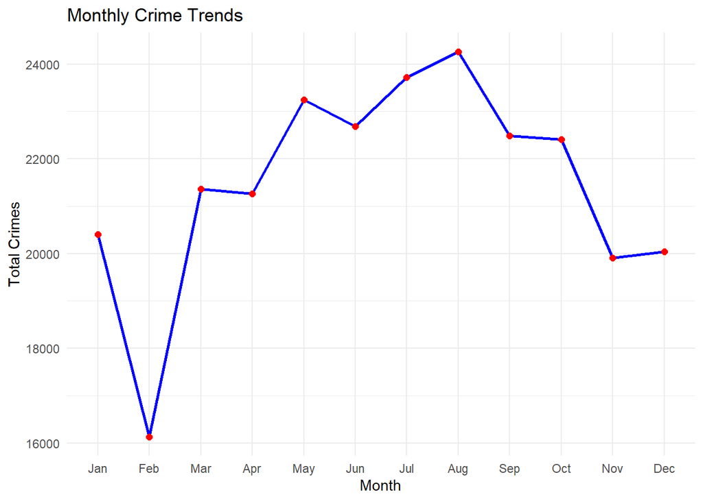

### Hourly Crime Distribution

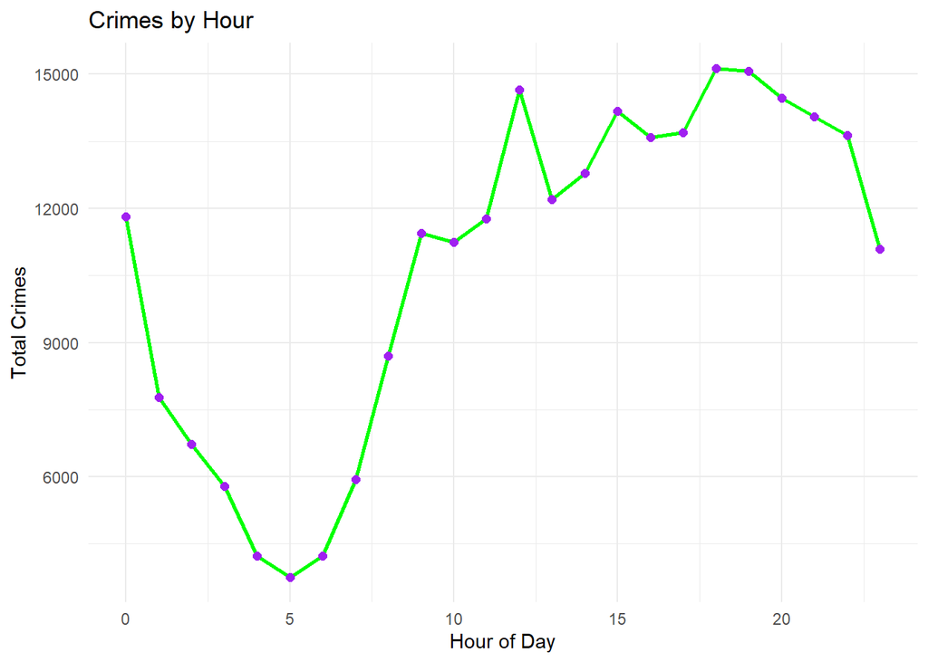

```r
crimes %>%
  group_by(Hour) %>%
  summarise(Total = n()) %>%
  ggplot(aes(x = Hour, y = Total)) +
  geom_line(color = "green", linewidth = 1) +
  geom_point(color = "purple", size = 2) +
  labs(title = "Crimes by Hour", x = "Hour of Day", y = "Total Crimes") +
  theme_minimal()
```